# Group 6 Assignment 3

4/11/2020

Group Members: Jonathan Levin, Chenyue Lu, Kathleen Sucipto, Dany Thorpe

### Part 1: Exploratory Analysis

We are using two data sets:

A. The States Historical Data in this [COVID Tracking Project](https://covidtracking.com/api), combined with

B. The [days state-wide school closure are enforced](https://www.edweek.org/ew/section/multimedia/map-coronavirus-and-school-closures.htm)

#### A. COVID Tracking Project

This data could be used to explore the number of positive tests, number of negative tests, pending tests, hospitalizations per state over time. Unfortunately, both ICU and ventilator data contain a lot of missing data.

This information could be used to visualize **number of cases** over time, for example:

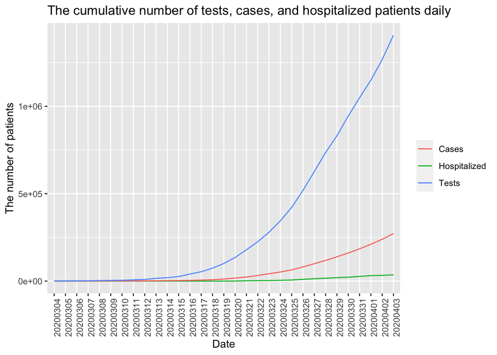

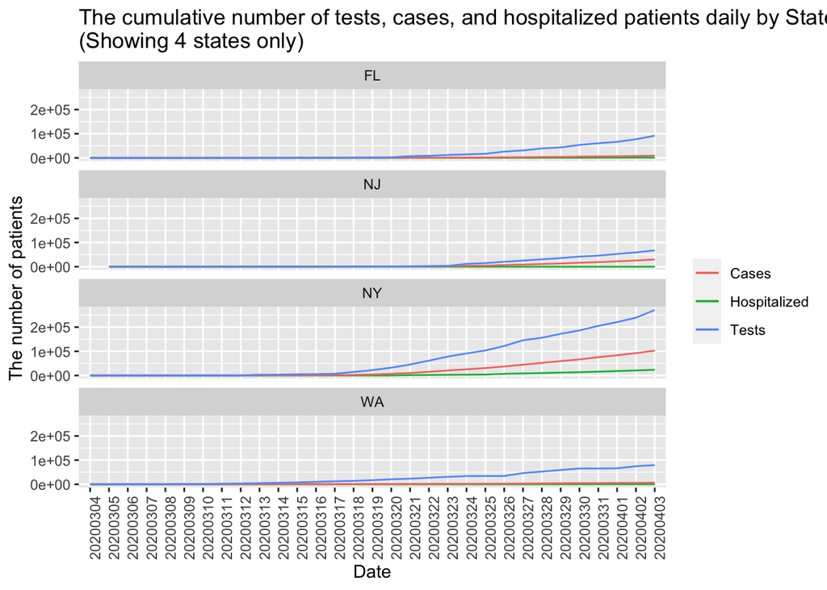

This could also be used graph the **rate of change** over time (i.e. daily positive rate), for example:

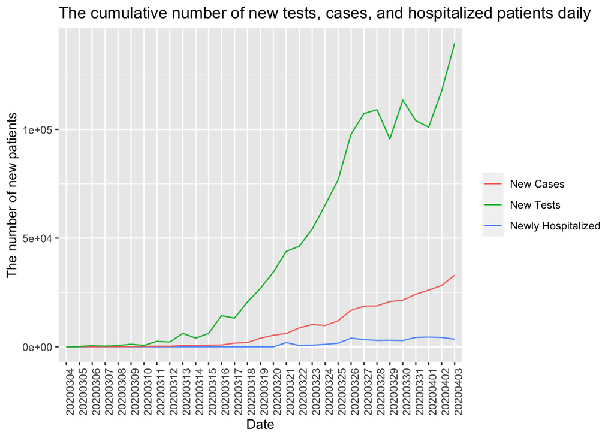

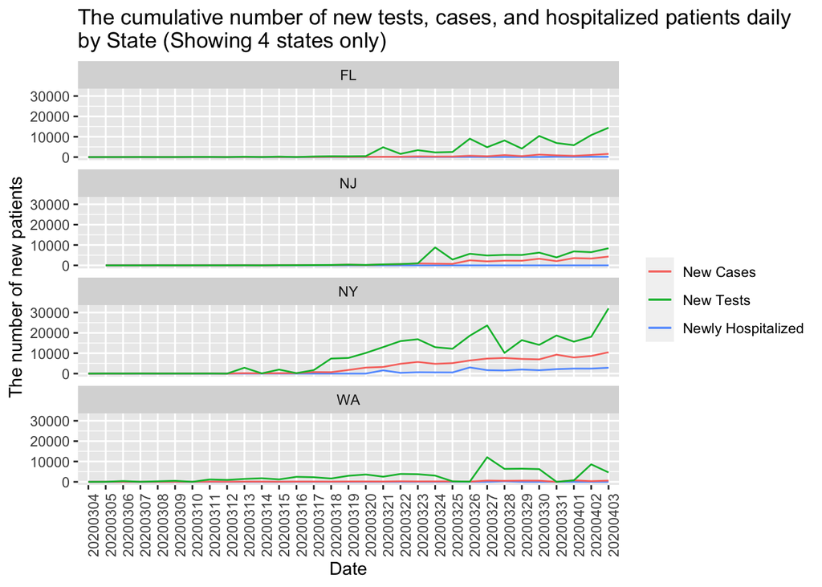

The latter analysis is a proxy measure for the value of R0 (number of people who catch a disease from one contagious person).

#### B. School closure data set

This data can be used to determine the date of mandated state school closure per date, for example:

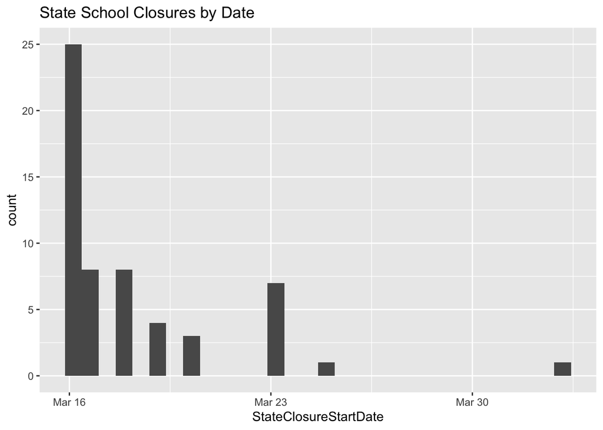

And could also be used to look at the number of individuals affected per state by the closing (or state population could be added to make a proportion):

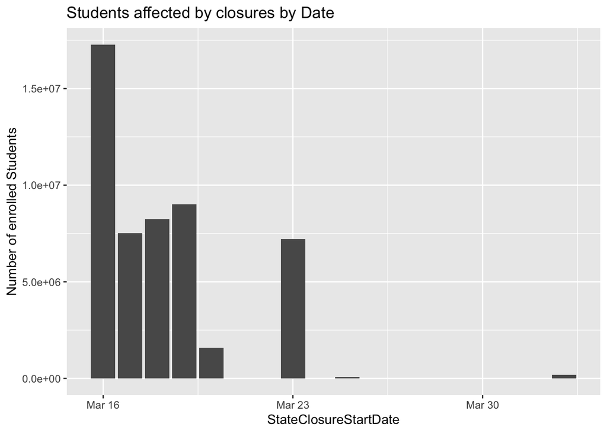

#### Combining data

By combining the two data sets, one could derive the following information:

- How timing of school closures affected the rate of new cases overall and by state
- Comparing ‘R0’ or the positive case rate before and after an intervention policy like school closures is enacted
- The ‘incubation time’ between an intervention policy like school closures and when there is an effect in the number of cases or hospitalizations
- How states’ testing capacity correlated with school closure policies

Our goal is to explore whether school closures demonstrate direct impact on the rate of new cases.

### Part 2: Identify target audience

The target audience will mainly be the **policy makers** who, for instance, decides when to enact school closures and for how long and further evaluate its effectiveness for future considerations. Our visualizations could also be used by public health researchers and the general public.

### Part 3: Visualization tasks

Our visualization tasks will be:

- Graphical display when school closures occurred across the US ([example](https://en.unesco.org/covid19/educationresponse))
- Overall positive case rate and hospitalization rate in the US **centered** around school closure date
- Visual interaction focusing on the impact of virus incubation time with regards to delays in the effect of a policy like school closing
- State-by-state evaluation focusing on the timing of school closures, testing availability, positive test rate, the increasing cases rate, and the hospitalization rate